# Tópico 2 - Importação de dados

Document Author

16/05/2022

- Anote suas dificuldades e dúvidas para que possamos conversar na próxima aula!
- Nas aulas passadas, alguns exercícios foram pulados e estão neste script para que possamos praticar.

## Tópico 1 - R Base

No código a seguir, criamos um vetor de alturas, chamado `valores_alturas`, que contém 100 valores aleatórios, com reposição, de valores entre 1.50 à 1.90. A ideia é simular a altura de 100 pessoas para fazer o exercício :) (sim, sabemos que tem pessoas que estão fora dessa faixa de altura, mas escolhi esse intervalo por ser mais comum).

```r
alturas_possiveis <- 150:190/100
alturas_possiveis
```

```
##  [1] 1.50 1.51 1.52 1.53 1.54 1.55 1.56 1.57 1.58 1.59 1.60 1.61 1.62 1.63 1.64
## [16] 1.65 1.66 1.67 1.68 1.69 1.70 1.71 1.72 1.73 1.74 1.75 1.76 1.77 1.78 1.79
## [31] 1.80 1.81 1.82 1.83 1.84 1.85 1.86 1.87 1.88 1.89 1.90
```

```r
valores_alturas <- sample(alturas_possiveis, # valores possiveis para sorteio
                          size = 100, # quantos valores quero "sortear"
                          replace = TRUE) # esses valores podem ser repetidos

valores_alturas
```

```
##   [1] 1.68 1.75 1.65 1.62 1.86 1.82 1.74 1.90 1.73 1.61 1.74 1.51 1.80 1.77 1.85
##  [16] 1.79 1.80 1.54 1.54 1.57 1.89 1.50 1.81 1.78 1.82 1.64 1.77 1.87 1.89 1.88
##  [31] 1.71 1.57 1.60 1.53 1.60 1.51 1.52 1.56 1.82 1.79 1.74 1.57 1.90 1.53 1.60
##  [46] 1.90 1.87 1.64 1.56 1.58 1.80 1.87 1.65 1.80 1.88 1.57 1.78 1.65 1.84 1.73
##  [61] 1.78 1.88 1.67 1.78 1.76 1.75 1.64 1.71 1.57 1.85 1.64 1.78 1.90 1.81 1.89
##  [76] 1.86 1.58 1.72 1.86 1.58 1.90 1.66 1.52 1.55 1.79 1.78 1.73 1.57 1.54 1.75
##  [91] 1.64 1.89 1.52 1.52 1.53 1.51 1.56 1.54 1.85 1.76
```

1. Usando as funções aprendidas hoje, verifique se a classe deste vetor é `numeric`:

```r
class(valores_alturas)
```

```
## [1] "numeric"
```

2. Imagine que uma nova pessoa entrou no grupo, mas ela não se sentiu confortável em falar qual é a altura dela! Não sabemos qual é a altura dela, então tentem adicionar essa altura no vetor também. Lembre-se que podemos usar a função c() para combinar elementos!

```r
valores_alturas <- c(valores_alturas, NA)
valores_alturas
```

```
##   [1] 1.68 1.75 1.65 1.62 1.86 1.82 1.74 1.90 1.73 1.61 1.74 1.51 1.80 1.77 1.85
##  [16] 1.79 1.80 1.54 1.54 1.57 1.89 1.50 1.81 1.78 1.82 1.64 1.77 1.87 1.89 1.88
##  [31] 1.71 1.57 1.60 1.53 1.60 1.51 1.52 1.56 1.82 1.79 1.74 1.57 1.90 1.53 1.60
##  [46] 1.90 1.87 1.64 1.56 1.58 1.80 1.87 1.65 1.80 1.88 1.57 1.78 1.65 1.84 1.73
##  [61] 1.78 1.88 1.67 1.78 1.76 1.75 1.64 1.71 1.57 1.85 1.64 1.78 1.90 1.81 1.89
##  [76] 1.86 1.58 1.72 1.86 1.58 1.90 1.66 1.52 1.55 1.79 1.78 1.73 1.57 1.54 1.75
##  [91] 1.64 1.89 1.52 1.52 1.53 1.51 1.56 1.54 1.85 1.76   NA
```

```r
sort(valores_alturas)
```

```
##   [1] 1.50 1.51 1.51 1.51 1.52 1.52 1.52 1.52 1.53 1.53 1.53 1.54 1.54 1.54 1.54
##  [16] 1.55 1.56 1.56 1.56 1.57 1.57 1.57 1.57 1.57 1.57 1.58 1.58 1.58 1.60 1.60
##  [31] 1.60 1.61 1.62 1.64 1.64 1.64 1.64 1.64 1.65 1.65 1.65 1.66 1.67 1.68 1.71
##  [46] 1.71 1.72 1.73 1.73 1.73 1.74 1.74 1.74 1.75 1.75 1.75 1.76 1.76 1.77 1.77
##  [61] 1.78 1.78 1.78 1.78 1.78 1.78 1.79 1.79 1.79 1.80 1.80 1.80 1.80 1.81 1.81
##  [76] 1.82 1.82 1.82 1.84 1.85 1.85 1.85 1.86 1.86 1.86 1.87 1.87 1.87 1.88 1.88
##  [91] 1.88 1.89 1.89 1.89 1.89 1.90 1.90 1.90 1.90 1.90
```

3. Usando funções do R, verifique quantos valores temos nesse vetor.

```r
length(valores_alturas)
```

```
## [1] 101
```

4. Calcule a média da altura das pessoas do grupo. A função `mean()` calcula a média.

```r
mean(valores_alturas, na.rm = TRUE)
```

```
## [1] 1.7091
```

5. Quais são as alturas máximas e mínimas do grupo? Use as funções `min()` e `max()` para encontrar esse valores.

```r
max(valores_alturas, na.rm = TRUE)
```

```
## [1] 1.9
```

```r
min(valores_alturas, na.rm = TRUE)
```

```
## [1] 1.5
```

6. Qual é a mediana desse conjunto de valores? Use a função `median()` para calcular.

```r
median(valores_alturas, na.rm = TRUE)
```

```
## [1] 1.735
```

7. Calcule a variância e o desvio padrão deste conjunto de valores usando as funções `var()` e `sd()`.

```r
var(valores_alturas, na.rm = TRUE)
```

```
## [1] 0.0166911
```

```r
sd(valores_alturas, na.rm = TRUE)
```

```
## [1] 0.129194
```

## Tópico 2 - Importação

Primeiro, precisamos carregar o pacote tidyverse, que será usado ao longo do script:

```r
library(tidyverse)
```

Precisamos carregar as bases também:

```r
dados_pnud <- read_csv2("dados/base_pnud_min.csv")
dicionario_pnud <- read_csv2("dados/dicionario_base_pnud_min.csv")
```

1. Explore a base do dicionário do pnud. Quantas colunas tem? Quantas linhas tem? Quais informações essa pequena base apresenta? Busque usar funções em R.

```r
glimpse(dicionario_pnud)
```

```
## Rows: 11
## Columns: 4
## $ sigla      <chr> "espvida", "gini", "idhm", "idhm_e", "idhm_l", "idhm_r", "m…
## $ nome_curto <chr> "Esperança de vida ao nascer", "Índice de Gini", "IDHM", "I…
## $ nome_longo <chr> "Esperança de vida ao nascer", "Índice de Gini", "Índice de…
## $ definicao  <chr> "Número médio de anos que as pessoas deverão viver a partir…
```

2. Use a função unique() para criar um vetor com as siglas dos estados do Brasil.

```r
estados_br <- sort(unique(dados_pnud$uf_sigla))
```

Exercícios: final da aula

- Vamos usar os dados para o ano de 2010. Para isso é necessário filtrar os dados, e vamos ver como fazer isso no próximo tópico!

```r
dados_pnud_2010 <-  filter(dados_pnud, ano == 2010)
```

1. Qual era a soma da população do Brasil em 2010?

```r
# Soma de população em 2010:
sum(dados_pnud_2010$pop)
```

```
## [1] 187645425
```

2. Qual era a média da esperança de vida da população do Brasil em 2010?

```r
# média: esperança de vida
mean(dados_pnud_2010$espvida)
```

```
## [1] 73.08791
```

Arredonde o valor encontrado nesse exercício, para apresentar 1 casa decimal:

```r
# arredondando para ter uma casa decimal
round(mean(dados_pnud_2010$espvida), 1)
```

```
## [1] 73.1
```

E a média ponderada?

```r
weighted.mean(dados_pnud_2010$espvida, dados_pnud_2010$pop)
```

```
## [1] 74.41148
```

3. Qual era a mediana da esperança de vida da população do Brasil em 2010?

```r
# mediana: esperança de vida
median(dados_pnud_2010$espvida)
```

```
## [1] 73.47
```

4. Qual era a variância da esperança de vida da população do Brasil em 2010?

```r
# variância: esperança de vida
var(dados_pnud_2010$espvida)
```

```
## [1] 7.187854
```

5. Qual era o desvio padrão da esperança de vida da população do Brasil em 2010?

```r
# desvio padrão: esperança de vida
sd(dados_pnud_2010$espvida)
```

```
## [1] 2.681017
```

```r
# maior valor encontrado
max(dados_pnud_2010$espvida)
```

```
## [1] 78.64
```

```r
# menor valor encontrado
min(dados_pnud_2010$espvida)
```

```
## [1] 65.3
```

## Tópico 3 - Manipulação

Esse tópico será abordado na aula seguinte, mas o objetivo deste exercício é já ir se acostumando com o conteúdo! A ideia é que vocês interpretem os códigos a seguir (olhando o código e o resultado), e tentem explicar o que acham que aconteceu.

Para ajudar, segue um resumo de algumas funções útes:

- `select()`: seleciona colunas da base de dados
- `filter()`: filtra linhas da base de dados
- `arrange()`: reordena as linhas da base de dados
- `mutate()`: cria novas colunas da base de dados (ou atualiza as colunas existentes)
- `group_by()` + `summarise()`: agrupa e sumariza da base de dados
- `count()`: faz uma contagem por grupos

Já vimos que podemos filtar os dados da seguinte forma: no exemplo a seguir buscamos as linhas onde o ano seja igual à 2010.

```r
filter(dados_pnud, ano == 2010)
```

```
## # A tibble: 5,562 × 15
##      ano muni_id muni_nm   uf_sigla regiao_nm  idhm idhm_e idhm_l idhm_r espvida
##    <dbl>   <dbl> <chr>     <chr>    <chr>     <dbl>  <dbl>  <dbl>  <dbl>   <dbl>
##  1  2010 1100015 ALTA FLO… RO       Norte     0.641  0.526  0.763  0.657    70.8
##  2  2010 1100023 ARIQUEMES RO       Norte     0.702  0.6    0.806  0.716    73.4
##  3  2010 1100031 CABIXI    RO       Norte     0.65   0.559  0.757  0.65     70.4
##  4  2010 1100049 CACOAL    RO       Norte     0.718  0.62   0.821  0.727    74.3
##  5  2010 1100056 CEREJEIR… RO       Norte     0.692  0.602  0.799  0.688    72.9
##  6  2010 1100064 COLORADO… RO       Norte     0.685  0.584  0.814  0.676    73.8
##  7  2010 1100072 CORUMBIA… RO       Norte     0.613  0.473  0.774  0.63     71.4
##  8  2010 1100080 COSTA MA… RO       Norte     0.611  0.493  0.751  0.616    70.0
##  9  2010 1100098 ESPIGÃO … RO       Norte     0.672  0.536  0.819  0.691    74.2
## 10  2010 1100106 GUAJARÁ-… RO       Norte     0.657  0.519  0.823  0.663    74.4
## # … with 5,552 more rows, and 5 more variables: rdpc <dbl>, gini <dbl>,
## #   pop <dbl>, lat <dbl>, lon <dbl>
```

Podemos reescrever esse código desta forma, usando o pipe, que é usado para criar sequências de códigos:

```r
dados_pnud |>
  filter(ano == 2010)
```

```
## # A tibble: 5,562 × 15
##      ano muni_id muni_nm   uf_sigla regiao_nm  idhm idhm_e idhm_l idhm_r espvida
##    <dbl>   <dbl> <chr>     <chr>    <chr>     <dbl>  <dbl>  <dbl>  <dbl>   <dbl>
##  1  2010 1100015 ALTA FLO… RO       Norte     0.641  0.526  0.763  0.657    70.8
##  2  2010 1100023 ARIQUEMES RO       Norte     0.702  0.6    0.806  0.716    73.4
##  3  2010 1100031 CABIXI    RO       Norte     0.65   0.559  0.757  0.65     70.4
##  4  2010 1100049 CACOAL    RO       Norte     0.718  0.62   0.821  0.727    74.3
##  5  2010 1100056 CEREJEIR… RO       Norte     0.692  0.602  0.799  0.688    72.9
##  6  2010 1100064 COLORADO… RO       Norte     0.685  0.584  0.814  0.676    73.8
##  7  2010 1100072 CORUMBIA… RO       Norte     0.613  0.473  0.774  0.63     71.4
##  8  2010 1100080 COSTA MA… RO       Norte     0.611  0.493  0.751  0.616    70.0
##  9  2010 1100098 ESPIGÃO … RO       Norte     0.672  0.536  0.819  0.691    74.2
## 10  2010 1100106 GUAJARÁ-… RO       Norte     0.657  0.519  0.823  0.663    74.4
## # … with 5,552 more rows, and 5 more variables: rdpc <dbl>, gini <dbl>,
## #   pop <dbl>, lat <dbl>, lon <dbl>
```

Vamos ver o pipe em outro exemplo! O que você acha que a função abaixo fez? Execute e veja o resultado. Pode escrever com as suas palavras :)

SUA INTERPRETAÇÃO: …

```r
dados_pnud_2010 |>
  count(uf_sigla)
```

```
## # A tibble: 27 × 2
##    uf_sigla     n
##    <chr>    <int>
##  1 AC          22
##  2 AL         102
##  3 AM          62
##  4 AP          16
##  5 BA         417
##  6 CE         184
##  7 DF           1
##  8 ES          78
##  9 GO         245
## 10 MA         217
## # … with 17 more rows
```

SUA INTERPRETAÇÃO: …

```r
dados_pnud_2010 |>
  count(regiao_nm)
```

```
## # A tibble: 5 × 2
##   regiao_nm        n
##   <chr>        <int>
## 1 Centro-Oeste   465
## 2 Nordeste      1794
## 3 Norte          449
## 4 Sudeste       1667
## 5 Sul           1187
```

SUA INTERPRETAÇÃO: …

```r
dados_pnud_2010 |>
  count(regiao_nm) |>
  arrange(n)
```

```
## # A tibble: 5 × 2
##   regiao_nm        n
##   <chr>        <int>
## 1 Norte          449
## 2 Centro-Oeste   465
## 3 Sul           1187
## 4 Sudeste       1667
## 5 Nordeste      1794
```

SUA INTERPRETAÇÃO: …

```r
dados_pnud_2010 |>
  select(muni_nm, uf_sigla, pop)
```

```
## # A tibble: 5,562 × 3
##    muni_nm               uf_sigla   pop
##    <chr>                 <chr>    <dbl>
##  1 ALTA FLORESTA D'OESTE RO       22429
##  2 ARIQUEMES             RO       88730
##  3 CABIXI                RO        6156
##  4 CACOAL                RO       76876
##  5 CEREJEIRAS            RO       16815
##  6 COLORADO DO OESTE     RO       18204
##  7 CORUMBIARA            RO        8397
##  8 COSTA MARQUES         RO       13246
##  9 ESPIGÃO D'OESTE       RO       27791
## 10 GUAJARÁ-MIRIM         RO       38203
## # … with 5,552 more rows
```

SUA INTERPRETAÇÃO: …

```r
dados_pnud_2010 |>
  select(muni_nm, uf_sigla, pop) |>
  filter(pop > 1000000)
```

```
## # A tibble: 14 × 3
##    muni_nm        uf_sigla      pop
##    <chr>          <chr>       <dbl>
##  1 MANAUS         AM        1787596
##  2 BELÉM          PA        1381212
##  3 FORTALEZA      CE        2424565
##  4 RECIFE         PE        1522583
##  5 SALVADOR       BA        2647972
##  6 Belo Horizonte MG        2356178
##  7 RIO DE JANEIRO RJ        6262802
##  8 CAMPINAS       SP        1071443
##  9 GUARULHOS      SP        1212934
## 10 SÃO PAULO      SP       11166543
## 11 CURITIBA       PR        1740627
## 12 PORTO ALEGRE   RS        1393799
## 13 GOIÂNIA        GO        1297017
## 14 BRASÍLIA       DF        2541714
```

SUA INTERPRETAÇÃO: …

```r
dados_pnud_2010 |>
  select(muni_nm, uf_sigla, pop) |>
  filter(pop > 1000000) |>
  arrange(desc(pop))
```

```
## # A tibble: 14 × 3
##    muni_nm        uf_sigla      pop
##    <chr>          <chr>       <dbl>
##  1 SÃO PAULO      SP       11166543
##  2 RIO DE JANEIRO RJ        6262802
##  3 SALVADOR       BA        2647972
##  4 BRASÍLIA       DF        2541714
##  5 FORTALEZA      CE        2424565
##  6 Belo Horizonte MG        2356178
##  7 MANAUS         AM        1787596
##  8 CURITIBA       PR        1740627
##  9 RECIFE         PE        1522583
## 10 PORTO ALEGRE   RS        1393799
## 11 BELÉM          PA        1381212
## 12 GOIÂNIA        GO        1297017
## 13 GUARULHOS      SP        1212934
## 14 CAMPINAS       SP        1071443
```

SUA INTERPRETAÇÃO: …

```r
dados_pnud_2010 |>
  select(muni_nm, uf_sigla, pop) |>
  filter(pop > 1000000) |>
  arrange(desc(pop)) |>
  mutate(pop_milhoes = pop/1000000)
```

```
## # A tibble: 14 × 4
##    muni_nm        uf_sigla      pop pop_milhoes
##    <chr>          <chr>       <dbl>       <dbl>
##  1 SÃO PAULO      SP       11166543       11.2
##  2 RIO DE JANEIRO RJ        6262802        6.26
##  3 SALVADOR       BA        2647972        2.65
##  4 BRASÍLIA       DF        2541714        2.54
##  5 FORTALEZA      CE        2424565        2.42
##  6 Belo Horizonte MG        2356178        2.36
##  7 MANAUS         AM        1787596        1.79
##  8 CURITIBA       PR        1740627        1.74
##  9 RECIFE         PE        1522583        1.52
## 10 PORTO ALEGRE   RS        1393799        1.39
## 11 BELÉM          PA        1381212        1.38
## 12 GOIÂNIA        GO        1297017        1.30
## 13 GUARULHOS      SP        1212934        1.21
## 14 CAMPINAS       SP        1071443        1.07
```

SUA INTERPRETAÇÃO: …

```r
dados_pnud_2010 |>
  select(muni_nm, uf_sigla, pop) |>
  filter(pop > 1000000) |>
  arrange(desc(pop)) |>
  mutate(pop_milhoes = round(pop/1000000, 2))
```

```
## # A tibble: 14 × 4
##    muni_nm        uf_sigla      pop pop_milhoes
##    <chr>          <chr>       <dbl>       <dbl>
##  1 SÃO PAULO      SP       11166543       11.2
##  2 RIO DE JANEIRO RJ        6262802        6.26
##  3 SALVADOR       BA        2647972        2.65
##  4 BRASÍLIA       DF        2541714        2.54
##  5 FORTALEZA      CE        2424565        2.42
##  6 Belo Horizonte MG        2356178        2.36
##  7 MANAUS         AM        1787596        1.79
##  8 CURITIBA       PR        1740627        1.74
##  9 RECIFE         PE        1522583        1.52
## 10 PORTO ALEGRE   RS        1393799        1.39
## 11 BELÉM          PA        1381212        1.38
## 12 GOIÂNIA        GO        1297017        1.3
## 13 GUARULHOS      SP        1212934        1.21
## 14 CAMPINAS       SP        1071443        1.07
```

# Tópico 4 - Gráficos

Esse tópico será apenas uma pincelada, pois não temos tempo para abordar com mais detalhes. No R, criamos gráficos usando código! Experimente usar a seguinte função: `esquisse::esquisser()`

Explore o esquisse, e depois tente gerar um gráfico similar ao gráfico a seguir:

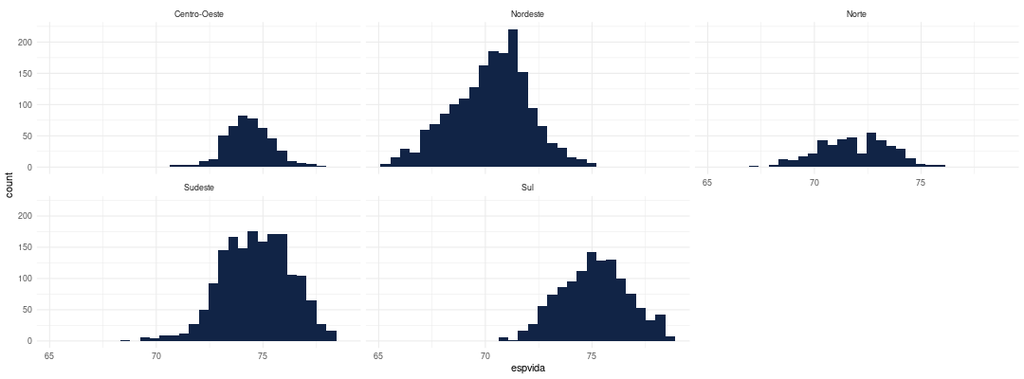

Os dados usados foram `dados_pnud_2010`. O tipo de gráfico gerado é um histograma, e usamos as variáveis referentes à esperança de vida (`espvida`) e a região do Brasil (`regiao_nm`).

Dica: Adicionamos essas informações nos eixos X e no Facet (você vai descobrir o que é quando abrir o esquisse!).

O esquisse permite que você copie e cole o código do gráfico!

A vignette do esquisse pode ajudar também: https://cran.r-project.org/web/packages/esquisse/vignettes/get-started.html

Adicione o código do gráfico a seguir:

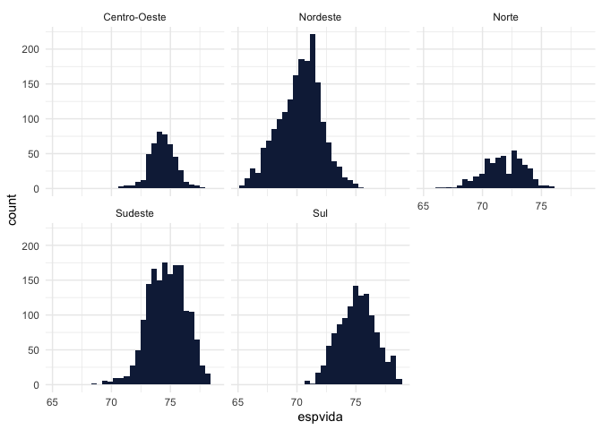

```r
ggplot(dados_pnud_2010) +
  aes(x = espvida) +
  geom_histogram(bins = 30L, fill = "#112446") +
  theme_minimal() +
  facet_wrap(vars(regiao_nm))
```